# **Bancolombia**: Predicción precios de vivienda, *2 Visualización y correlación*

```python
import pandas as pd
import seaborn as sns
import matplotlib.pyplot as plt
pd.set_option("display.max_columns", None)
```

```python
#carga de los dos dataset previamente tratados (train y test)
df_train = pd.read_excel('/content/drive/MyDrive/Personal/test_bancolombia/Prueba Modelo_data/train.xlsx', index_col=0)
df_test = pd.read_excel('/content/drive/MyDrive/Personal/test_bancolombia/Prueba Modelo_data/test.xlsx', index_col=0)
```

```python
df_train.info()
```

```
<class 'pandas.core.frame.DataFrame'>
Int64Index: 12857 entries, 0 to 12856
Data columns (total 49 columns):
 #   Column                           Non-Null Count  Dtype
---  ------                           --------------  -----
 0   municipio_inmueble               12857 non-null  object
 1   tipo_inmueble                    12857 non-null  object
 2   demanda_interes                  12857 non-null  int64
 3   alamedas                         12857 non-null  int64
 4   nivel_equipamiento_comercial     12857 non-null  int64
 5   observaciones_altura_permitida   12857 non-null  int64
 6   antejardin                       12857 non-null  object
 7   indice_ocupacion                 12857 non-null  float64
 8   unidades                         12857 non-null  object
 9   alcantarillado_en_el_sector      12857 non-null  int64
```

[output cut: 41 more lines]

```python
df_test.info()
```

```
<class 'pandas.core.frame.DataFrame'>
Int64Index: 5385 entries, 0 to 5384
Data columns (total 48 columns):
 #   Column                           Non-Null Count  Dtype
---  ------                           --------------  -----
 0   municipio_inmueble               5385 non-null   object
 1   tipo_inmueble                    5385 non-null   object
 2   demanda_interes                  5385 non-null   int64
 3   alamedas                         5385 non-null   int64
 4   nivel_equipamiento_comercial     5385 non-null   int64
 5   observaciones_altura_permitida   5385 non-null   int64
 6   antejardin                       5385 non-null   object
 7   indice_ocupacion                 5385 non-null   int64
 8   unidades                         5385 non-null   int64
 9   alcantarillado_en_el_sector      5385 non-null   int64
```

[output cut: 40 more lines]

## Correlación

Antes de continuar vamos a revisar las correlación de las diferentes variables con el objetivo con el fin de realizar un segundo filtro y enfocarnos en las variables que presenten más relación con el objetivo

```python
correlacion = df_train.corr()
```

```python
correlacion
```

|  | demanda_interes | alamedas | nivel_equipamiento_comercial | observaciones_altura_permitida | indice_ocupacion | alcantarillado_en_el_sector | acueducto_en_el_sector | gas_en_el_sector | energia_en_el_sector | telefono_en_el_sector | vias_pavimentadas | estrato | arborizacion | ciclo_rutas | sometido_a_propiedad_horizontal | area_valorada | habitaciones | estar_habitacion | cuarto_servicio | closet | sala | bano_privado | bano_social | bano_servicio | cocina | estudio | balcon | terraza | patio_interior | … |
| --- | --- | --- | --- | --- | --- | --- | --- | --- | --- | --- | --- | --- | --- | --- | --- | --- | --- | --- | --- | --- | --- | --- | --- | --- | --- | --- | --- | --- | --- | --- |
| demanda_interes | 1.000000 | 0.104749 | 0.064309 | -0.091544 | -0.006421 | 0.100413 | 0.072619 | 0.087259 | 0.046415 | 0.081191 | 0.102945 | 0.152836 | 0.075522 | 0.081262 | 0.136198 | -0.008257 | -0.038740 | -0.001679 | 0.038935 | 0.088272 | -0.020144 | 0.022368 | 0.021022 | 0.030374 | -0.035117 | 0.045008 | 0.093871 | -0.014343 | -0.047490 | … |
| alamedas | 0.104749 | 1.000000 | 0.087353 | -0.105413 | -0.013224 | 0.039982 | 0.016353 | 0.054752 | 0.015892 | 0.062353 | 0.090393 | 0.184447 | 0.231380 | 0.512223 | 0.145678 | -0.000741 | -0.027685 | 0.038053 | 0.076279 | 0.118507 | -0.011749 | 0.012484 | 0.068216 | 0.077187 | -0.027642 | 0.124442 | 0.069602 | -0.020084 | -0.070650 | … |
| nivel_equipamiento_comercial | 0.064309 | 0.087353 | 1.000000 | -0.039260 | 0.000275 | 0.178508 | 0.053565 | 0.133748 | 0.032885 | 0.138263 | 0.145807 | 0.145293 | 0.050078 | 0.095175 | 0.093419 | -0.007671 | 0.011541 | 0.005951 | 0.049990 | 0.095400 | 0.026093 | 0.028468 | 0.034122 | 0.039601 | 0.033933 | 0.032040 | 0.073974 | -0.031836 | -0.029943 | … |
| observaciones_altura_permitida | -0.091544 | -0.105413 | -0.039260 | 1.000000 | -0.011670 | -0.023048 | -0.004327 | -0.057303 | -0.014003 | -0.062255 | -0.135149 | -0.305549 | -0.087991 | -0.133261 | -0.720404 | 0.025672 | 0.299066 | 0.023660 | -0.066621 | -0.157197 | 0.171697 | -0.025843 | 0.159393 | -0.065045 | 0.258607 | -0.095035 | -0.181488 | 0.158216 | 0.354998 | … |
| indice_ocupacion | -0.006421 | -0.013224 | 0.000275 | -0.011670 | 1.000000 | 0.003066 | 0.001812 | -0.014716 | 0.001494 | 0.005061 | 0.005895 | -0.024218 | -0.008050 | -0.013279 | -0.037269 | -0.001531 | -0.035695 | 0.215960 | 0.043549 | -0.029952 | 0.045613 | 0.005844 | 0.022984 | 0.063080 | -0.060790 | 0.056214 | -0.013201 | 0.031942 | -0.008023 | … |
| alcantarillado_en_el_sector | 0.100413 | 0.039982 | 0.178508 | -0.023048 | 0.003066 | 1.000000 | 0.482582 | 0.474819 | 0.325498 | 0.373318 | 0.293224 | 0.083859 | 0.081519 | 0.050657 | 0.133216 | -0.013405 | -0.000759 | -0.060200 | -0.026904 | 0.049444 | 0.015423 | -0.032403 | 0.010278 | -0.041425 | 0.037394 | 0.002933 | 0.041422 | -0.053173 | 0.005270 | … |
| acueducto_en_el_sector | 0.072619 | 0.016353 | 0.053565 | -0.004327 | 0.001812 | 0.482582 | 1.000000 | 0.347062 | 0.519738 | 0.290568 | 0.221470 | 0.075786 | 0.072738 | 0.023985 | 0.067851 | -0.000504 | 0.007021 | 0.007864 | -0.005668 | 0.055061 | 0.035612 | 0.009153 | 0.016001 | -0.003218 | 0.026444 | 0.022887 | 0.032608 | 0.000583 | 0.009799 | … |
| gas_en_el_sector | 0.087259 | 0.054752 | 0.133748 | -0.057303 | -0.014716 | 0.474819 | 0.347062 | 1.000000 | 0.220701 | 0.346120 | 0.289884 | 0.116843 | 0.093484 | 0.079254 | 0.147512 | -0.018085 | -0.024341 | -0.027126 | 0.008631 | 0.072494 | 0.027500 | -0.016987 | 0.001055 | 0.003355 | 0.011852 | 0.031034 | 0.069097 | -0.066796 | -0.012549 | … |
| energia_en_el_sector | 0.046415 | 0.015892 | 0.032885 | -0.014003 | 0.001494 | 0.325498 | 0.519738 | 0.220701 | 1.000000 | 0.207094 | 0.171200 | 0.056248 | 0.044162 | 0.013084 | 0.029071 | 0.003861 | 0.017788 | -0.006252 | 0.014919 | 0.038349 | 0.008638 | 0.020760 | 0.005138 | 0.005656 | 0.024529 | 0.011541 | 0.020961 | -0.004379 | -0.000585 | … |
| telefono_en_el_sector | 0.081191 | 0.062353 | 0.138263 | -0.062255 | 0.005061 | 0.373318 | 0.290568 | 0.346120 | 0.207094 | 1.000000 | 0.295259 | 0.136857 | 0.140807 | 0.050102 | 0.126502 | -0.004038 | -0.004884 | 0.009190 | 0.028723 | 0.085420 | 0.032143 | 0.014748 | 0.000916 | 0.027580 | 0.018884 | 0.039395 | 0.073109 | -0.032741 | -0.001470 | … |
| vias_pavimentadas | 0.102945 | 0.090393 | 0.145807 | -0.135149 | 0.005895 | 0.293224 | 0.221470 | 0.289884 | 0.171200 | 0.295259 | 1.000000 | 0.242063 | 0.111946 | 0.105439 | 0.215431 | -0.001559 | -0.005426 | 0.016109 | 0.049813 | 0.167527 | 0.009039 | 0.046200 | 0.028114 | 0.050725 | -0.002687 | 0.056308 | 0.084537 | -0.028842 | -0.071130 | … |
| estrato | 0.152836 | 0.184447 | 0.145293 | -0.305549 | -0.024218 | 0.083859 | 0.075786 | 0.116843 | 0.056248 | 0.136857 | 0.242063 | 1.000000 | 0.189014 | 0.189049 | 0.427704 | 0.004853 | -0.123195 | 0.124963 | 0.386392 | 0.449505 | -0.065266 | 0.327490 | 0.008982 | 0.364540 | -0.117784 | 0.253478 | 0.321883 | 0.024201 | -0.240131 | … |
| arborizacion | 0.075522 | 0.231380 | 0.050078 | -0.087991 | -0.008050 | 0.081519 | 0.072738 | 0.093484 | 0.044162 | 0.140807 | 0.111946 | 0.189014 | 1.000000 | 0.119286 | 0.099293 | -0.007214 | -0.052581 | 0.012350 | 0.061894 | 0.107650 | -0.021540 | 0.028411 | -0.002088 | 0.060339 | -0.050359 | 0.043788 | 0.056363 | -0.024509 | -0.050903 | … |
| ciclo_rutas | 0.081262 | 0.512223 | 0.095175 | -0.133261 | -0.013279 | 0.050657 | 0.023985 | 0.079254 | 0.013084 | 0.050102 | 0.105439 | 0.189049 | 0.119286 | 1.000000 | 0.190813 | 0.011551 | -0.056058 | -0.010984 | 0.055058 | 0.107432 | -0.029979 | -0.020443 | 0.076030 | 0.057703 | -0.038566 | 0.104652 | 0.007652 | -0.030341 | -0.132087 | … |
| sometido_a_propiedad_horizontal | 0.136198 | 0.145678 | 0.093419 | -0.720404 | -0.037269 | 0.133216 | 0.067851 | 0.147512 | 0.029071 | 0.126502 | 0.215431 | 0.427704 | 0.099293 | 0.190813 | 1.000000 | -0.017871 | -0.305622 | -0.101376 | 0.048383 | 0.256554 | -0.194334 | 0.073533 | -0.176921 | 0.036674 | -0.252178 | 0.109589 | 0.251494 | -0.208411 | -0.453199 | … |
| area_valorada | -0.008257 | -0.000741 | -0.007671 | 0.025672 | -0.001531 | -0.013405 | -0.000504 | -0.018085 | 0.003861 | -0.004038 | -0.001559 | 0.004853 | -0.007214 | 0.011551 | -0.017871 | 1.000000 | 0.022600 | 0.029743 | 0.027120 | -0.000875 | 0.014814 | 0.022124 | 0.015105 | 0.022334 | 0.027537 | -0.010775 | -0.010024 | 0.039477 | 0.032012 | … |
| habitaciones | -0.038740 | -0.027685 | 0.011541 | 0.299066 | -0.035695 | -0.000759 | 0.007021 | -0.024341 | 0.017788 | -0.004884 | -0.005426 | -0.123195 | -0.052581 | -0.056058 | -0.305622 | 0.022600 | 1.000000 | 0.016598 | 0.035942 | 0.165228 | 0.383214 | 0.287198 | 0.370241 | 0.019767 | 0.590497 | -0.008917 | 0.018839 | 0.168346 | 0.302689 | … |
| estar_habitacion | -0.001679 | 0.038053 | 0.005951 | 0.023660 | 0.215960 | -0.060200 | 0.007864 | -0.027126 | -0.006252 | 0.009190 | 0.016109 | 0.124963 | 0.012350 | -0.010984 | -0.101376 | 0.029743 | 0.016598 | 1.000000 | 0.213965 | 0.091699 | 0.101147 | 0.163977 | 0.105513 | 0.305407 | -0.088746 | 0.189984 | 0.072821 | 0.171043 | 0.075537 | … |
| cuarto_servicio | 0.038935 | 0.076279 | 0.049990 | -0.066621 | 0.043549 | -0.026904 | -0.005668 | 0.008631 | 0.014919 | 0.028723 | 0.049813 | 0.386392 | 0.061894 | 0.055058 | 0.048383 | 0.027120 | 0.035942 | 0.213965 | 1.000000 | 0.269012 | -0.022872 | 0.280755 | 0.065320 | 0.779204 | -0.033666 | 0.184340 | 0.124004 | 0.139182 | 0.010663 | … |
| closet | 0.088272 | 0.118507 | 0.095400 | -0.157197 | -0.029952 | 0.049444 | 0.055061 | 0.072494 | 0.038349 | 0.085420 | 0.167527 | 0.449505 | 0.107650 | 0.107432 | 0.256554 | -0.000875 | 0.165228 | 0.091699 | 0.269012 | 1.000000 | -0.003955 | 0.338373 | 0.091245 | 0.240799 | -0.031808 | 0.218266 | 0.258622 | 0.059131 | -0.076861 | … |
| sala | -0.020144 | -0.011749 | 0.026093 | 0.171697 | 0.045613 | 0.015423 | 0.035612 | 0.027500 | 0.008638 | 0.032143 | 0.009039 | -0.065266 | -0.021540 | -0.029979 | -0.194334 | 0.014814 | 0.383214 | 0.101147 | -0.022872 | -0.003955 | 1.000000 | 0.116816 | 0.228011 | 0.031241 | 0.569054 | 0.021084 | 0.028173 | 0.130746 | 0.164430 | … |
| bano_privado | 0.022368 | 0.012484 | 0.028468 | -0.025843 | 0.005844 | -0.032403 | 0.009153 | -0.016987 | 0.020760 | 0.014748 | 0.046200 | 0.327490 | 0.028411 | -0.020443 | 0.073533 | 0.022124 | 0.287198 | 0.163977 | 0.280755 | 0.338373 | 0.116816 | 1.000000 | -0.236663 | 0.263525 | 0.112742 | 0.177058 | 0.247940 | 0.179760 | 0.035563 | … |
| bano_social | 0.021022 | 0.068216 | 0.034122 | 0.159393 | 0.022984 | 0.010278 | 0.016001 | 0.001055 | 0.005138 | 0.000916 | 0.028114 | 0.008982 | -0.002088 | 0.076030 | -0.176921 | 0.015105 | 0.370241 | 0.105513 | 0.065320 | 0.091245 | 0.228011 | -0.236663 | 1.000000 | 0.037921 | 0.341906 | 0.101985 | 0.016326 | 0.107036 | 0.161957 | … |
| bano_servicio | 0.030374 | 0.077187 | 0.039601 | -0.065045 | 0.063080 | -0.041425 | -0.003218 | 0.003355 | 0.005656 | 0.027580 | 0.050725 | 0.364540 | 0.060339 | 0.057703 | 0.036674 | 0.022334 | 0.019767 | 0.305407 | 0.779204 | 0.240799 | 0.031241 | 0.263525 | 0.037921 | 1.000000 | -0.078630 | 0.220140 | 0.114214 | 0.135301 | -0.003912 | … |
| cocina | -0.035117 | -0.027642 | 0.033933 | 0.258607 | -0.060790 | 0.037394 | 0.026444 | 0.011852 | 0.024529 | 0.018884 | -0.002687 | -0.117784 | -0.050359 | -0.038566 | -0.252178 | 0.027537 | 0.590497 | -0.088746 | -0.033666 | -0.031808 | 0.569054 | 0.112742 | 0.341906 | -0.078630 | 1.000000 | -0.070845 | -0.000985 | 0.136340 | 0.226649 | … |
| estudio | 0.045008 | 0.124442 | 0.032040 | -0.095035 | 0.056214 | 0.002933 | 0.022887 | 0.031034 | 0.011541 | 0.039395 | 0.056308 | 0.253478 | 0.043788 | 0.104652 | 0.109589 | -0.010775 | -0.008917 | 0.189984 | 0.184340 | 0.218266 | 0.021084 | 0.177058 | 0.101985 | 0.220140 | -0.070845 | 1.000000 | 0.191005 | 0.097898 | -0.037668 | … |
| balcon | 0.093871 | 0.069602 | 0.073974 | -0.181488 | -0.013201 | 0.041422 | 0.032608 | 0.069097 | 0.020961 | 0.073109 | 0.084537 | 0.321883 | 0.056363 | 0.007652 | 0.251494 | -0.010024 | 0.018839 | 0.072821 | 0.124004 | 0.258622 | 0.028173 | 0.247940 | 0.016326 | 0.114214 | -0.000985 | 0.191005 | 1.000000 | -0.057298 | -0.152796 | … |
| terraza | -0.014343 | -0.020084 | -0.031836 | 0.158216 | 0.031942 | -0.053173 | 0.000583 | -0.066796 | -0.004379 | -0.032741 | -0.028842 | 0.024201 | -0.024509 | -0.030341 | -0.208411 | 0.039477 | 0.168346 | 0.171043 | 0.139182 | 0.059131 | 0.130746 | 0.179760 | 0.107036 | 0.135301 | 0.136340 | 0.097898 | -0.057298 | 1.000000 | 0.145043 | … |
| patio_interior | -0.047490 | -0.070650 | -0.029943 | 0.354998 | -0.008023 | 0.005270 | 0.009799 | -0.012549 | -0.000585 | -0.001470 | -0.071130 | -0.240131 | -0.050903 | -0.132087 | -0.453199 | 0.032012 | 0.302689 | 0.075537 | 0.010663 | -0.076861 | 0.164430 | 0.035563 | 0.161957 | -0.003912 | 0.226649 | -0.037668 | -0.152796 | 0.145043 | 1.000000 | … |
| jardin | -0.034041 | 0.004150 | -0.026431 | 0.117269 | 0.089547 | -0.133318 | -0.014244 | -0.138985 | -0.004523 | -0.081010 | -0.053903 | 0.024915 | 0.010927 | -0.045586 | -0.183400 | 0.018578 | 0.073108 | 0.202009 | 0.135526 | 0.059231 | 0.059307 | 0.131078 | 0.081022 | 0.155754 | 0.004003 | 0.110183 | -0.021184 | 0.152052 | 0.174460 | … |
| zona_de_ropas | -0.018780 | -0.040234 | 0.023990 | 0.104831 | -0.036345 | 0.074162 | 0.046911 | 0.049618 | 0.027215 | 0.058574 | 0.021144 | -0.023497 | 0.023038 | -0.042589 | -0.080940 | 0.021407 | 0.357131 | -0.057440 | -0.009565 | 0.068064 | 0.369785 | 0.085632 | 0.193959 | -0.040554 | 0.532270 | -0.026061 | 0.049969 | 0.049852 | 0.061424 | … |
| zona_verde_privada | 0.002283 | 0.036898 | -0.090539 | 0.054644 | 0.119351 | -0.159350 | -0.036994 | -0.149512 | -0.007781 | -0.094677 | -0.080243 | 0.036273 | 0.017946 | -0.028409 | -0.125396 | 0.022538 | -0.003758 | 0.298993 | 0.150013 | 0.026870 | 0.056176 | 0.143876 | 0.040248 | 0.206122 | -0.074135 | 0.146605 | -0.018069 | 0.186113 | 0.104140 | … |
| local | -0.016542 | -0.024399 | 0.023489 | 0.137322 | 0.014112 | -0.004989 | -0.005599 | -0.020517 | -0.004362 | -0.007186 | -0.000171 | -0.068753 | -0.006017 | -0.026554 | -0.172444 | 0.002088 | 0.117917 | 0.027934 | 0.027096 | -0.069900 | 0.080179 | 0.020574 | 0.141649 | 0.007032 | 0.170171 | -0.040264 | -0.018905 | 0.051199 | 0.086932 | … |
| oficina | -0.000248 | 0.011412 | 0.008305 | 0.025741 | -0.001313 | -0.005438 | -0.006252 | 0.004133 | 0.003362 | 0.007551 | 0.009921 | 0.020936 | -0.007154 | 0.031282 | -0.043335 | -0.002819 | -0.034510 | 0.017635 | 0.025323 | -0.003365 | -0.008305 | 0.043415 | 0.043959 | 0.019128 | 0.017034 | 0.011715 | -0.008133 | 0.014174 | 0.034220 | … |
| bodega | -0.007329 | 0.006778 | -0.015377 | 0.053856 | -0.003076 | -0.123392 | -0.040016 | -0.075851 | -0.009276 | -0.078599 | -0.035437 | 0.021598 | -0.020656 | -0.012458 | -0.061066 | 0.000010 | 0.052521 | 0.027871 | 0.060720 | 0.041918 | 0.018483 | 0.048460 | 0.060143 | 0.056086 | 0.036349 | 0.046595 | -0.001654 | 0.066899 | 0.037714 | … |
| area_privada | -0.014479 | 0.020592 | -0.021872 | -0.024427 | -0.001340 | -0.015066 | 0.002340 | -0.012105 | -0.000813 | -0.001812 | 0.002679 | 0.043426 | 0.010329 | -0.003537 | 0.035315 | 0.019288 | -0.022472 | 0.004623 | 0.014554 | 0.009821 | -0.022433 | 0.007249 | -0.013070 | 0.012994 | -0.032254 | 0.007147 | 0.000384 | 0.003738 | -0.016272 | … |
| area_garaje | -0.000649 | 0.016166 | -0.001532 | -0.004326 | -0.000216 | 0.000961 | 0.000672 | 0.001713 | 0.000454 | 0.001876 | 0.002179 | -0.002803 | 0.004272 | -0.004805 | -0.013708 | -0.000630 | -0.013208 | 0.036637 | 0.021792 | -0.011057 | -0.017199 | -0.000965 | -0.000151 | 0.020424 | -0.022384 | 0.015301 | -0.006797 | 0.015124 | -0.005763 | … |
| area_terreno | -0.008690 | 0.001378 | -0.006248 | -0.007364 | -0.000404 | -0.033285 | -0.004656 | 0.000223 | -0.003937 | 0.000894 | 0.001662 | 0.005058 | 0.007020 | 0.005249 | -0.024606 | -0.001132 | -0.023408 | 0.050431 | 0.023498 | -0.007256 | 0.060826 | -0.000664 | 0.000039 | 0.054797 | -0.007936 | 0.026490 | 0.006926 | 0.035826 | -0.007571 | … |
| area_construccion | -0.016395 | -0.001740 | 0.012228 | 0.004599 | 0.161211 | -0.050388 | 0.002617 | -0.003527 | 0.002158 | 0.001717 | -0.001261 | -0.022229 | -0.016208 | -0.016133 | -0.053853 | -0.001819 | -0.018708 | 0.190277 | 0.023196 | -0.031305 | 0.079733 | 0.011216 | -0.001735 | 0.103541 | -0.039655 | 0.048145 | -0.003770 | 0.026529 | 0.001493 | … |
| area_deposito | -0.001217 | 0.017266 | 0.016278 | -0.016577 | -0.000828 | -0.031913 | -0.037450 | -0.009620 | 0.002122 | 0.007190 | 0.008374 | 0.021265 | 0.006626 | 0.023100 | -0.037711 | -0.002369 | -0.048150 | 0.104373 | 0.045765 | -0.004043 | 0.013894 | 0.016509 | 0.005524 | 0.071560 | -0.045091 | 0.062479 | -0.016403 | 0.042144 | -0.005414 | … |
| area_otros | -0.000571 | -0.012982 | 0.014511 | 0.014666 | 0.289992 | -0.024096 | 0.003279 | -0.000321 | 0.002702 | 0.006750 | -0.001965 | -0.013820 | -0.004292 | -0.020749 | -0.067426 | -0.002483 | -0.034938 | 0.260742 | 0.044897 | -0.026103 | 0.087733 | 0.018072 | 0.020881 | 0.138927 | -0.045670 | 0.084837 | -0.000448 | 0.052657 | 0.017045 | … |
| area_libre | -0.012249 | -0.000304 | 0.000366 | -0.002764 | 0.390106 | -0.059428 | -0.035111 | -0.011131 | 0.003293 | 0.008292 | -0.000398 | -0.025350 | -0.005355 | -0.009665 | -0.078051 | -0.003388 | -0.078701 | 0.381341 | 0.146312 | -0.059333 | 0.061085 | 0.005053 | 0.016345 | 0.186822 | -0.082117 | 0.100814 | -0.009819 | 0.047260 | 0.010726 | … |
| valor_total_avaluo | 0.005079 | 0.012265 | 0.006634 | 0.002050 | -0.000724 | -0.005598 | -0.012654 | -0.006229 | -0.005569 | -0.006674 | 0.000951 | 0.015331 | 0.004772 | 0.012185 | -0.002880 | 0.008036 | -0.006598 | 0.016402 | 0.004986 | -0.006822 | -0.006454 | 0.005333 | 0.009590 | 0.003915 | 0.010678 | 0.012133 | 0.010043 | -0.004875 | -0.001031 | … |
| nivel_servicios | 0.115385 | 0.064636 | 0.175083 | -0.058829 | -0.002362 | 0.744809 | 0.627175 | 0.764909 | 0.484209 | 0.749424 | 0.382573 | 0.148787 | 0.138419 | 0.072858 | 0.165005 | -0.012189 | -0.008558 | -0.022722 | 0.009741 | 0.093595 | 0.036081 | -0.004901 | 0.006879 | 0.002359 | 0.030642 | 0.035597 | 0.078752 | -0.055863 | -0.002726 | … |
| id | 0.017223 | 0.006761 | -0.008830 | -0.014393 | -0.029180 | 0.013400 | -0.001904 | 0.013153 | 0.008997 | -0.013910 | 0.005285 | 0.000952 | 0.002922 | -0.018532 | 0.044152 | -0.045839 | 0.015711 | -0.066132 | -0.030563 | 0.023851 | -0.008139 | 0.005481 | 0.002204 | -0.045946 | 0.015534 | -0.024491 | 0.032287 | -0.014146 | -0.003820 | … |

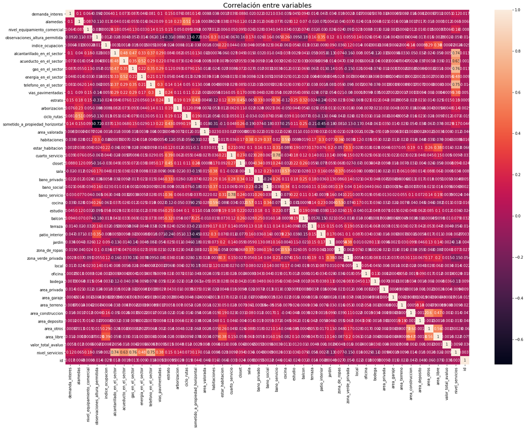

```python
plt.figure(figsize=(25,18))
ax=sns.heatmap(correlacion,annot=True)
ax.set_title('Correlación entre variables',fontsize=18)
```

```python
#revisemos las variables mas correlacionadas con el objetivo 'valor_total_avaluo'
correlacion['valor_total_avaluo'].sort_values(ascending=False)
```

```
valor_total_avaluo                 1.000000
bodega                             0.036052
estar_habitacion                   0.016402
estrato                            0.015331
zona_verde_privada                 0.014843
alamedas                           0.012265
ciclo_rutas                        0.012185
estudio                            0.012133
cocina                             0.010678
balcon                             0.010043
bano_social                        0.009590
area_terreno                       0.008755
area_valorada                      0.008036
nivel_equipamiento_comercial       0.006634
bano_privado                       0.005333
demanda_interes                    0.005079
cuarto_servicio                    0.004986
arborizacion                       0.004772
zona_de_ropas                      0.004085
area_privada                       0.004026
bano_servicio                      0.003915
observaciones_altura_permitida     0.002050
vias_pavimentadas                  0.000951
area_garaje                       -0.000268
indice_ocupacion                  -0.000724
area_deposito                     -0.001029
area_construccion                 -0.001030
patio_interior                    -0.001031
area_otros                        -0.001310
oficina                           -0.001355
area_libre                        -0.001597
jardin                            -0.002352
sometido_a_propiedad_horizontal   -0.002880
local                             -0.003407
terraza                           -0.004875
energia_en_el_sector              -0.005569
alcantarillado_en_el_sector       -0.005598
gas_en_el_sector                  -0.006229
sala                              -0.006454
habitaciones                      -0.006598
telefono_en_el_sector             -0.006674
closet                            -0.006822
nivel_servicios                   -0.009704
acueducto_en_el_sector            -0.012654
id                                -0.035815
Name: valor_total_avaluo, dtype: float64
```

```python
#retiramos variables no deseadas
no_deseadas = [
  'alcantarillado_en_el_sector',
  'acueducto_en_el_sector',
  'gas_en_el_sector',
  'energia_en_el_sector',
  'telefono_en_el_sector', #presentan altas correlaciones entre ellas y ya se trataron como una sola variable
  'bano_servicio', #correlacionada con cuarto servicio
  'ciclo_rutas' #correlacioanda con alamedas por su naturaleza se puede quitar
]
```

```python
df_train.drop(columns=no_deseadas, inplace=True)
df_test.drop(columns=no_deseadas, inplace=True)
```

```python
plt.figure(figsize=(25,18))
ax=sns.heatmap(df_train.corr(),annot=True)
ax.set_title('Correlación entre variables',fontsize=18)
```

[output not shown]

```python
df_train.info()
```

[output not shown]

Se exploraran las variables mas importantes (una eleccion personal) antes de comenzar el modelado

### Exploracion descriptivas

```python
df_train.describe()
```

[output not shown]

```python
to_delete = [
  'alamedas',
  'observaciones_altura_permitida',
  'indice_ocupacion',
  'estar_habitacion',
  'cuarto_servicio',
  'estudio',
  'balcon',
  'terraza',
  'jardin',
  'zona_verde_privada',
  'local',
  'oficina',
  'bodega',
  'area_deposito',   #Alerta Area 75% en 0'
  'area_otros',    #Alerta Area 75% en 0'
  'area_libre'
]
```

## Distribución variables de area

```python
#veremos la distribucion de un set numerico de variables (no categoricos ni ordinales)
subnumeric_set = [
  'area_privada',
 'area_garaje',
 'area_terreno',
 'area_construccion',
 'area_deposito',
 'area_otros',
 'area_libre',
 'area_valorada'
]
```

```python
#se utiliza asi debido a errores con seaborn en el entorno de google colab
def graficar_distribution(df,x_column,y_colum):
  plt.figure(dpi = 100)
  plt.scatter(df[x_column],df[y_colum], marker='*');
  plt.title(x_column)
  plt.show()
```

```python
for i in subnumeric_set:
  graficar_distribution(df_train,i,'valor_total_avaluo')
```

[output not shown]

```python
plt.figure(dpi = 100)
plt.scatter(df_train['area_valorada'],df_train['valor_total_avaluo'], marker='*');
plt.axis([0, 4000, 0, 30000000000])
plt.title(i)
plt.show()
```

[output not shown]

```python
plt.figure(dpi = 100)
plt.scatter(df_train['area_valorada'],df_train['valor_total_avaluo'], marker='*');
plt.axis([0, 4000, 0, 1000000000])
plt.title(i)
plt.show()
```

[output not shown]

```python
plt.figure(dpi = 100)
plt.scatter(df_train['area_valorada'],df_train['valor_total_avaluo'], marker='*');
plt.axis([0, 1000, 0, 1000000000])
plt.title(i)
plt.show()
```

[output not shown]

### estrato

```python
graficar_distribution(df_train,'estrato','valor_total_avaluo')
```

[output not shown]

En general como los valores tiene un rango tan alto los más pequeños pueden parecer cercanos a 0 absoluto, sin embargo, corresponden a sumas considerables. El conjunto de datos se encuentra bastante aglomerado en valores pequeños tanto de áreas como precio.

Hay una relación ascendente que se concentra entre los valores bajos de las diferentes áreas y el precio

```python
%%shell
jupyter nbconvert --to html '/content/drive/MyDrive/Personal/test_bancolombia/desarrollo/02_visualizacion_analisis/02_visualizacion.ipynb'
```